# Indicador de correspondência

## Apresentação

Este relatório apresenta resultados preliminares da amálise exploratória dos dados do Sistema de Gestão da Defesa Civil. Propõe-se a criação de um novo indicador que pode ser usado para avaliar a confiabilidade dos dados estudados bem como a eficiência dos canais de atendimento em triar as solicitações que entram no sistema.

O indicador consiste em um número em (%), representando a fração das amastras em que o ocorrência indicada na solicitação (ocorr_solic) é igual à ocorrência observada em campo e registrada pelo técnico no momento da vistoria (ocorr_vist).

## Os dados

Foram utilizados os regisstros do SGDC correspondentes ao período de 01/07/2004 a 31/12/2019, inicialmente contendo **147512 observações e 16 variáveis**.

```r
head(pdata)
```

```
##   cod_proc          data_solic cod_logra                 desc_logra
## 1   100990 2019-12-31 20:08:38      9330        RUA ÁLVARO BAQUEIRO
## 2   100989 2019-12-31 19:13:20      8116 ESTRADA DO COQUEIRO GRANDE
## 3    99790 2019-12-31 17:05:54      9126             RUA DA ADUTORA
## 4   100987 2019-12-31 16:49:36     21133     2ª TRAVESSA BOM PASTOR
## 5   100986 2019-12-31 16:36:40     23359           RUA OSCAR SEIXAS
## 6   100985 2019-12-31 16:32:40      9126             RUA DA ADUTORA
##   num_imov_solic        nome_bairro               desc_pb coord_xi_logra
## 1             6E             ITAPUA       ITAPUÃ/IPITANGA   -38.36292050
## 2      7-1ºANDAR  FAZENDA GRANDE II            CAJAZEIRAS   -38.39949100
## 3       121-CASA      SÃO CRISTOVÃO       ITAPUÃ/IPITANGA   -38.35523480
## 4        24-CASA CAMPINAS DE PIRAJÁ LIBERDADE/SAO CAETANO   -38.47318120
## 5            S/N             PIRAJA               VALÉRIA   -38.46944190
## 6         7-CASA      SAO CRISTOVAO       ITAPUÃ/IPITANGA   -38.35523480
##   coord_yi_logra           ocorr_solic desc_orig_solic tipo_vist_solic
## 1   -12.94140110  ALAGAMENTO DE IMÓVEL       199 / 156          IMÓVEL
## 2   -12.90519790           INFILTRAÇÃO       199 / 156          IMÓVEL
## 3   -12.91639220  ALAGAMENTO DE IMÓVEL       199 / 156          IMÓVEL
## 4   -12.92414910  ALAGAMENTO DE IMÓVEL       199 / 156          IMÓVEL
## 5   -12.90376450 AMEACA DE DESABAMENTO       199 / 156          IMÓVEL
## 6   -12.91639220  ALAGAMENTO DE IMÓVEL       199 / 156          IMÓVEL
##              ocorr_vist           data_vist tipo_vist_vist          desc_status
## 1  ALAGAMENTO DE IMÓVEL 2020-01-02 12:32:53         IMÓVEL            CONCLUÍDO
## 2     AVALIACAO DA AREA 2020-01-02 00:00:00         IMÓVEL          ENC. SOCIAL
## 3  ALAGAMENTO DE IMÓVEL 2020-01-02 00:00:00         IMÓVEL            CONCLUÍDO
## 4  ALAGAMENTO DE IMÓVEL 2020-01-03 09:41:21         IMÓVEL            CONCLUÍDO
## 5 AMEACA DE DESABAMENTO 2020-01-06 00:00:00         IMÓVEL            CONCLUÍDO
## 6  ALAGAMENTO DE IMÓVEL 2020-01-02 00:00:00         IMÓVEL ENC. SOCIAL E CHEFIA
```

### Filtragem

Para as análises pretendidas, o primeiro requisito é que fossem selecionadas apenas as solicitações que foram atendidas e que possuem um tipo de ocorrência registrado pelo técnico vistoriados. Assim, foram eliminadas as observações de acordo com o valor das variáveis:

Status da solicitação (desc_status): CANCELADO, BLOQUEADO, PENDENTE, NÃO VISUALIZADA e VISTORIA PROGRAMADA. Canal de abertura (orig_solic): ABERTA EM CAMPO, OFÍCIO e OUVIDORIA.

Optou-se por suprimir as solicitações com orig_solic = *ABERTA EM CAMPO* pois, como as solicitações são também abertas no momento da vistoria pelo técnico vistoriador, ocorr_solic e ocorr_vist devem, por regra, serem iguais, o que desbalancearia a amostra. As solicitações abertas via *OFÍCIO* e *OUVIDORIA* foram desconsideradas por fugirem do escopo de interesse da análise.

```r
pdata <- pdata[!(pdata$desc_status == "CANCELADO"),]
pdata <- pdata[!(pdata$desc_status == "BLOQUEADO"),]
pdata <- pdata[!(pdata$desc_status == "PENDENTE"),]
pdata <- pdata[!(pdata$desc_status == "NÃO VISUALIZADA"),]
pdata <- pdata[!(pdata$desc_status == "VISTORIA PROGRAMADA"),]
pdata <- pdata[!(pdata$desc_orig_solic == "ABERTA EM CAMPO"),]
pdata <- pdata[!(pdata$desc_orig_solic == "OFICIO"),]
pdata <- pdata[!(pdata$desc_orig_solic == "OUVIDORIA"),]
pdata <- pdata[!(pdata$ocorr_vist == "NULL"),]
```

### Modelagem

```r
alagamentos <- c("AVALIAÇÃO DE IMÓVEL ALAGADO", "ALAGAMENTO DE IMÓVEL", "ALAGAMENTO DE ÁREA")
pdata$ocorr_solic <- ifelse(pdata$ocorr_solic %in% alagamentos, "ALAGAMENTO", pdata$ocorr_solic)
pdata$ocorr_vist <- ifelse(pdata$ocorr_vist %in% alagamentos, "ALAGAMENTO", pdata$ocorr_vist)
```

Por fim, criamos uma nova coluna no dataset, que deverá ter valor VERDADEIRO ( *TRUE* ) se a ocorrência indicada na solicitação e a observada na vistoria coincidirem e FALSO ( *FALSE* ) caso sejam diferentes.

O conjunto de dados final contem 88.760 observações e 17 variáveis.

```
##   cod_proc          data_solic cod_logra                 desc_logra
## 1   100990 2019-12-31 20:08:38      9330        RUA ÁLVARO BAQUEIRO
## 2   100989 2019-12-31 19:13:20      8116 ESTRADA DO COQUEIRO GRANDE
## 3    99790 2019-12-31 17:05:54      9126             RUA DA ADUTORA
## 4   100987 2019-12-31 16:49:36     21133     2ª TRAVESSA BOM PASTOR
## 5   100986 2019-12-31 16:36:40     23359           RUA OSCAR SEIXAS
## 6   100985 2019-12-31 16:32:40      9126             RUA DA ADUTORA
##   num_imov_solic        nome_bairro               desc_pb coord_xi_logra
## 1             6E             ITAPUA       ITAPUÃ/IPITANGA   -38.36292050
## 2      7-1ºANDAR  FAZENDA GRANDE II            CAJAZEIRAS   -38.39949100
## 3       121-CASA      SÃO CRISTOVÃO       ITAPUÃ/IPITANGA   -38.35523480
## 4        24-CASA CAMPINAS DE PIRAJÁ LIBERDADE/SAO CAETANO   -38.47318120
## 5            S/N             PIRAJA               VALÉRIA   -38.46944190
## 6         7-CASA      SAO CRISTOVAO       ITAPUÃ/IPITANGA   -38.35523480
##   coord_yi_logra           ocorr_solic desc_orig_solic tipo_vist_solic
```

[output cut: 20 more lines]

## Análises

### Univariada

[figure not shown]

Calculando essa tabela para *ORITENTAÇÃO TÉCNCIA*, um tipo de ocorrência coringa dentro do sistema, selecionado quando a ocorrência observada não se encaixa em nenhuma das tipologias disponíveis, observamos que aproximadamente 1/4 das solicitações são indicadas posteriormente pelo técnico como *AMEAÇA DE DESABAMENTO*. A maior parte é classidicada tanbém como *ORIENTAÇÃO TÉCNICA*, o que abre espaço para novas análises mais aprofundadas para verificar, talvez a partir das intervenções indicadas, se são atendimentos que fogem do escopo da Defesa Civil, ou mesmo identificar novas tipologias a serem inseridas na lista de ocorrências.

```
## # A tibble: 19 x 3
##    ocorr_vist                               n    freq
##    <chr>                                <int>   <dbl>
##  1 ORIENTAÇÃO TÉCNICA                    1715 54.7
##  2 AMEACA DE DESABAMENTO                  762 24.3
##  3 AMEACA DE DESLIZAMENTO                 190  6.05
##  4 INFILTRAÇÃO                            161  5.13
##  5 ALAGAMENTO                             102  3.25
##  6 DESLIZAMENTO DE TERRA                   35  1.12
##  7 AVALIACAO DA AREA                       31  0.988
##  8 DESABAMENTO DE IMOVEL                   29  0.924
##  9 AMEACA DE DESABAMENTO DE MURO           26  0.829
## 10 INCENDIO                                24  0.765
## 11 DESABAMENTO PARCIAL                     15  0.478
## 12 ARVORE AMEACANDO CAIR                   14  0.446
## 13 DESABAMENTO DE MURO                     13  0.414
## 14 PISTA ROMPIDA                           12  0.382
## 15 DESTELHAMENTO                            4  0.127
## 16 POSTE AMEAÇANDO CAIR                     2  0.0637
## 17 ARMAZENAMENTO DE MATERIAIS PERIGOSOS     1  0.0319
## 18 ARVORE CAIDA                             1  0.0319
## 19 GALHO DE ÁRVORE CAÍDO                    1  0.0319
```

### Multivariada

Nesta seção dispomos as observações feitas a partir do cruzamento do Indicador (C) com outras variáveis, como canal de ocorrência, data de abertura do chamado e local.

#### Qauntidade de solicitações e data de abertura

Buscando investigar se o número de solicitações que entram por dia interfete no Valor de C, traçamos um gráfico de dispersão relacionado ambas as variáveis para *DESLIZAMENTO DE TERRA*.

[figure not shown]

```
##  year(data_solic) date(data_solic)     ocorr_solic           n_solic
##  Min.   :2005     Min.   :2005-02-09   Length:390         Min.   : 10.00
##  1st Qu.:2006     1st Qu.:2006-05-23   Class :character   1st Qu.: 14.25
##  Median :2010     Median :2010-05-04   Mode  :character   Median : 24.00
##  Mean   :2011     Mean   :2011-05-31                      Mean   : 40.62
##  3rd Qu.:2015     3rd Qu.:2015-05-17                      3rd Qu.: 47.00
##  Max.   :2019     Max.   :2019-12-31                      Max.   :268.00
##        C
##  Min.   :0.07143
##  1st Qu.:0.38462
##  Median :0.50556
##  Mean   :0.49866
##  3rd Qu.:0.62500
##  Max.   :0.90000
```

```
## [1] 0.2783083
```

```
##
##  Pearson's product-moment correlation
##
## data:  dt$n_solic and dt$C
## t = 5.7075, df = 388, p-value = 2.28e-08
## alternative hypothesis: true correlation is not equal to 0
## 95 percent confidence interval:
##  0.1840938 0.3674553
## sample estimates:
##       cor
## 0.2783083
```

#### Caracterização da distribuição e testes de normalidade.

A convergência para um valor à medida que o número de solicitações aumenta aponta que C, interpretada como uma variável aleatória, deve seguir uma distribuição de probabilidade normal. Para confirmar tal hipótese, faremos análises gráficas e testes estatísticos.

OS gráficos de boxplot, histograma e q-q plot nos dão uma noção visual do formato da distribuição.

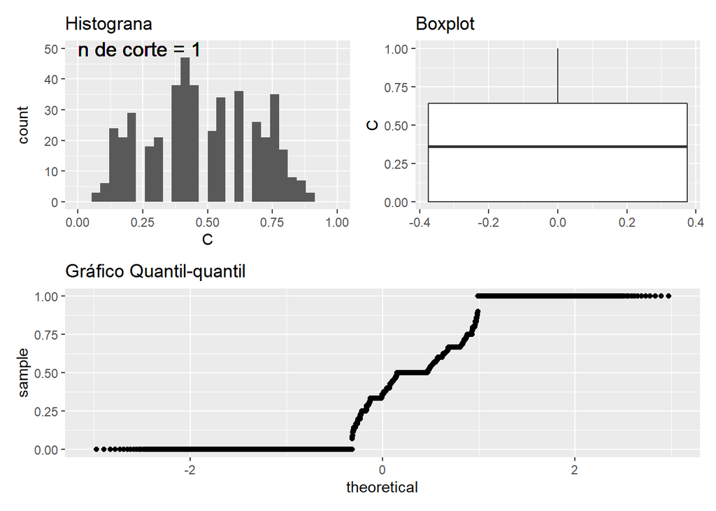

O Histograma aponta que a distribuição se aproxima do formato de “sino” à medida que aumentamis o n de corte, o que induz à idaia da normalidade dos dados. Da mesma forma, o boxplot e o gráfico quantil-quantil - que relaciona os quantís de uma amostra normal teórica com os quantís dos dados estudados - apontam para uma distribuição normal a partir de um número mínimo de solicitações por dia (n de corte).

Existindo indícios visuais, realizamos o teste estatístico de Shapiro-Wilk e calculamos um valor mínimo de solicitações por dia para a partir de quanto a amostra pode ser considerada normalmente distribuida.

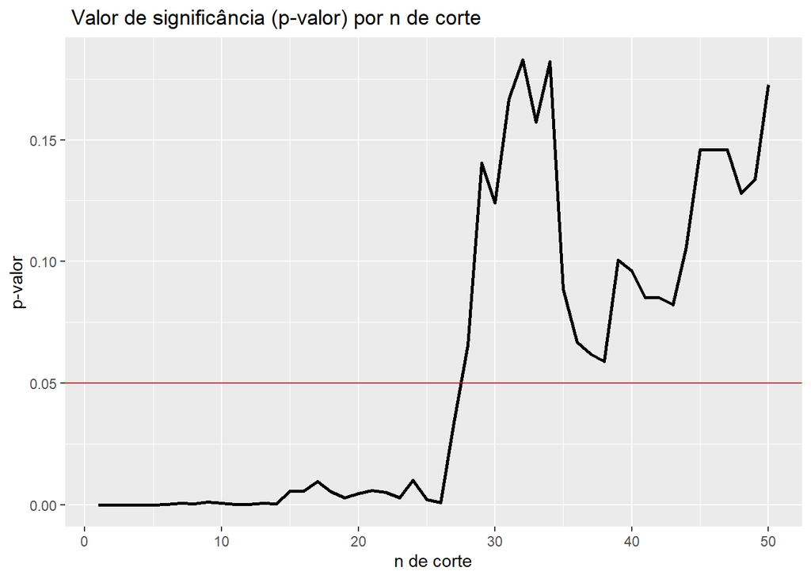

```
## [1] 28
```

```
## [1] 253
```

```
## [1] 184
```

```
## [1] 0.9126317
```

#### Canal de abertura

Sendo C uma métrica de verdadeiro-positivos, ou uma taxa de acertos, podemos apresentar FP = 1- C como uma métrica complementar que mede a taxa de falso-positivos (erros na indicação do tipo de ocorrência) na nossa base de dados.

Estudar a variação de FP de acordo com a forma como as solicitações entram no sistema pode nos dar uma dimensão da qualidade da triagem feita pelos canais de atendimento. Espera-se que o atendente seja capaz de ouvir o relato do cidadão e registrá-lo no sistema de forma concisa, captando os detalhes cruciais e fornecendo aos setores responsáveis pelo roteiro de vistoria informções confiáveis para definir a prioridade de atendimento.

Para as análises a seguir, serão consideradas as ocorrências de *AMEAÇA DE DESLIZAMENTO* e *DESLIZAMENTO DE TERRA*, dada a sua relevância na rotina do órgão e sua homogeneidade durante o periíodo analisado.

Sob essa perspectiva, analisamos a hipótese, que é um senso comum dentro da CODESAL: *“Desde que saiu da sede do órgão, em 2015, a qualidade do atendimento 199 caiu”*. Essa afirmação parte da premissa que, enquanto na sede, os atendentes do 199 poderiam ser melhor orientados pelos técnicos, podendo tirar dúvidas e receber correções imediatas.

Além disso, os atendentes do Call Center não desenvolvem uma especialiação no atendimento de Defesa Civil, uma vez que recepcionam também chamados para outras Secretarias. É rezoável considerar, então, que o atendimento presencial da CODESAL, aqui entitulado *PESSOALMENTE* deve apresentar una taxa de erro no mínimo menor que o atendimento via 199.

Afirmação 1: A taxa de erro do atendimento 199 deve aumentar a partir de 2015. Afirmação 2: A taxa de erro do atendimento presencial (PESSOALMENTE) é menor que a do atendimento 199.

O gráfico abaixo descreve a variação da taxa de erros (FP) dos canais de atendimento com o passar dos anos.

[figure not shown]

As taxas de erra do 199 e do atendimento presencial apresentam comportamento relativamente regular até 2015, sobrepondo-se em determinados momentos e alternando em outros. É possivel observar que a taxa de falsos-positivos do 199 cai a partir de 2014 e continua em queda depois de 2015, quuando esse atendimento sai da sede da CODESAL. Já o FP do atendimento presencial cai significativamente a partir de 2015, chegando no patamar dos 25%. Contudo, ambas as taxas voltam a convergir em 2019 para um valor comum. Tal comportamento aponta que o indicador é influenciado por outro fenômeno, externo à essa análise inical.

[figure not shown]